# Introductory Data Science & Machine Learning

### Step 2: Exploration (Exploratory Data Analysis)

Let's have a glance of the data.

```python
data_clsf.head()
```

|  | fixed acidity | volatile acidity | citric acid | residual sugar | chlorides | free sulfur dioxide | total sulfur dioxide | density | pH | sulphates | alcohol | quality |
| --- | --- | --- | --- | --- | --- | --- | --- | --- | --- | --- | --- | --- |
| 0 | 7.4 | 0.70 | 0.00 | 1.9 | 0.076 | 11.0 | 34.0 | 0.9978 | 3.51 | 0.56 | 9.4 | 1 |
| 1 | 7.8 | 0.88 | 0.00 | 2.6 | 0.098 | 25.0 | 67.0 | 0.9968 | 3.20 | 0.68 | 9.8 | 1 |
| 2 | 7.8 | 0.76 | 0.04 | 2.3 | 0.092 | 15.0 | 54.0 | 0.9970 | 3.26 | 0.65 | 9.8 | 1 |
| 3 | 11.2 | 0.28 | 0.56 | 1.9 | 0.075 | 17.0 | 60.0 | 0.9980 | 3.16 | 0.58 | 9.8 | 1 |
| 4 | 7.4 | 0.70 | 0.00 | 1.9 | 0.076 | 11.0 | 34.0 | 0.9978 | 3.51 | 0.56 | 9.4 | 1 |

What about the data shape and datatypes?

```python
print("""
No of columns: {}
No of rows: {}
No of categorical columns: {}
No of numerical columns: {}""".format(data_clsf.shape[1],
                                      data_clsf.shape[0],
                                      len(data_clsf.select_dtypes('O').columns),
                                      len(data_clsf.select_dtypes(['int', 'float']).columns)))
```

```
No of columns: 12
No of rows: 1599
No of categorical columns: 0
No of numerical columns: 12
```

Here, we don't have any categorical columns. That's easy!!

Let's have a descriptive statistical tables of the numeric columns.

```python
data_clsf.describe().transpose()
```

|  | count | mean | std | min | 25% | 50% | 75% | max |
| --- | --- | --- | --- | --- | --- | --- | --- | --- |
| fixed acidity | 1599.0 | 8.319637 | 1.741096 | 4.60000 | 7.1000 | 7.90000 | 9.200000 | 15.90000 |
| volatile acidity | 1599.0 | 0.527821 | 0.179060 | 0.12000 | 0.3900 | 0.52000 | 0.640000 | 1.58000 |
| citric acid | 1599.0 | 0.270976 | 0.194801 | 0.00000 | 0.0900 | 0.26000 | 0.420000 | 1.00000 |
| residual sugar | 1599.0 | 2.538806 | 1.409928 | 0.90000 | 1.9000 | 2.20000 | 2.600000 | 15.50000 |
| chlorides | 1599.0 | 0.087467 | 0.047065 | 0.01200 | 0.0700 | 0.07900 | 0.090000 | 0.61100 |
| free sulfur dioxide | 1599.0 | 15.874922 | 10.460157 | 1.00000 | 7.0000 | 14.00000 | 21.000000 | 72.00000 |
| total sulfur dioxide | 1599.0 | 46.467792 | 32.895324 | 6.00000 | 22.0000 | 38.00000 | 62.000000 | 289.00000 |
| density | 1599.0 | 0.996747 | 0.001887 | 0.99007 | 0.9956 | 0.99675 | 0.997835 | 1.00369 |
| pH | 1599.0 | 3.311113 | 0.154386 | 2.74000 | 3.2100 | 3.31000 | 3.400000 | 4.01000 |
| sulphates | 1599.0 | 0.658149 | 0.169507 | 0.33000 | 0.5500 | 0.62000 | 0.730000 | 2.00000 |
| alcohol | 1599.0 | 10.422983 | 1.065668 | 8.40000 | 9.5000 | 10.20000 | 11.100000 | 14.90000 |
| quality | 1599.0 | 1.096310 | 0.407354 | 0.00000 | 1.0000 | 1.00000 | 1.000000 | 2.00000 |

How's the distribution of numerical columns?

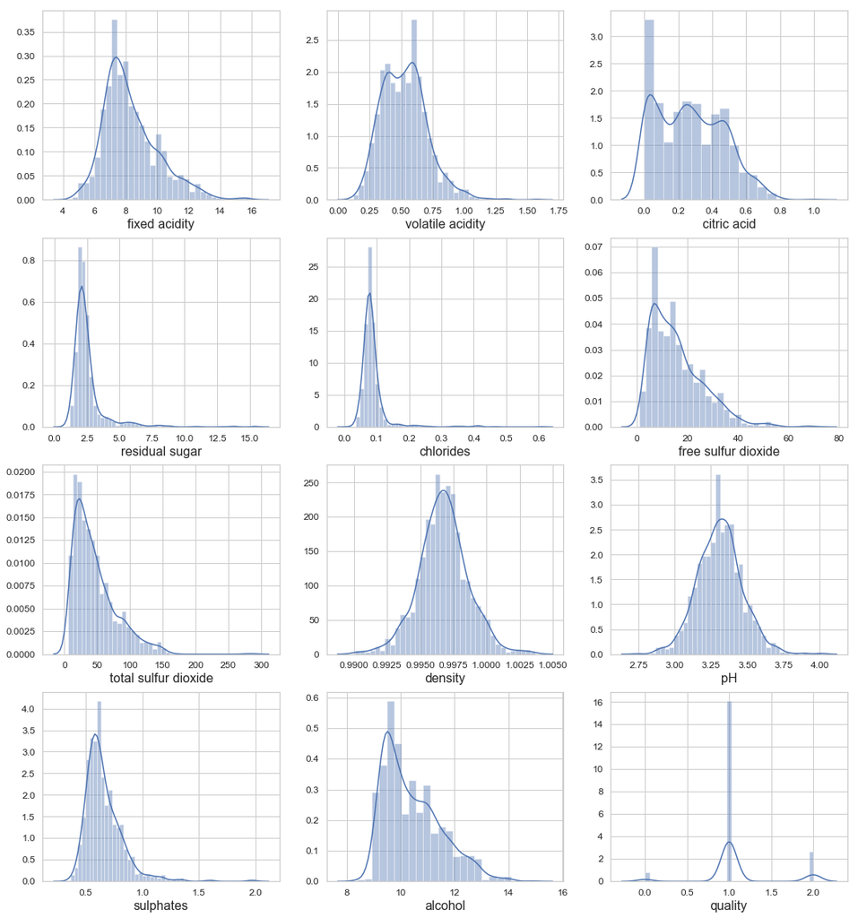

```python
import matplotlib.pyplot as plt
%matplotlib inline
import seaborn as sns
sns.set()
import numpy as np
import warnings
warnings.filterwarnings('ignore')

def plot_distribution(data, features):
    i = 0
    plt.figure()
    col = 3
    row = int(np.ceil(len(features)/col))
    fig, ax = plt.subplots(row,col,figsize=(18,20))
    sns.set_style("whitegrid")

    for feature in features:
        i += 1
        plt.subplot(row,col,i);
        sns.distplot(data[feature])
        plt.xlabel(feature, fontsize=16)
        locs, labels = plt.xticks()
        plt.tick_params(axis='x', which='major', labelsize=12)
        plt.tick_params(axis='y', which='major', labelsize=12)
    plt.show();

plot_distribution(data_clsf, data_clsf.columns)
```

OOHH MY GOOOOOSSHHH!!

Let's quickly check the correlations between the columns?

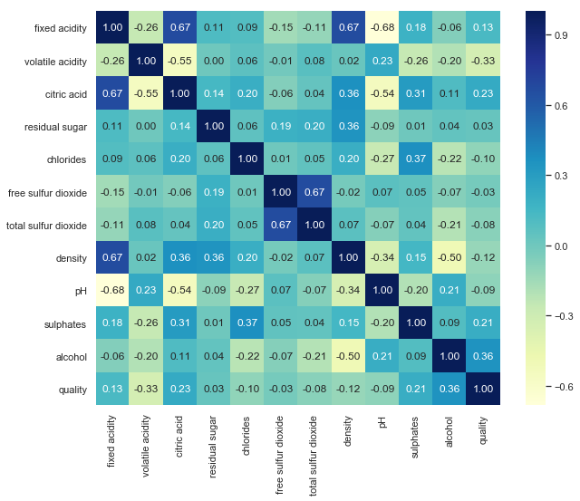

```python
corr = data_clsf.corr()
fig, ax = plt.subplots(figsize=(10,8))
sns.heatmap(corr,
            xticklabels=corr.columns.values,
            yticklabels=corr.columns.values,
            annot=True, fmt=".2f", cmap="YlGnBu");
```

### Step 3: Preprocessing

Are there any **missing values**?

```python
pd.DataFrame(data_clsf.isnull().sum(), columns=['Missing Values'])
```

|  | Missing Values |
| --- | --- |
| fixed acidity | 0 |
| volatile acidity | 0 |
| citric acid | 0 |
| residual sugar | 0 |
| chlorides | 0 |
| free sulfur dioxide | 0 |
| total sulfur dioxide | 0 |
| density | 0 |
| pH | 0 |
| sulphates | 0 |
| alcohol | 0 |
| quality | 0 |

DAMN!! We are very lucky!! Still we've got no missing values!

What percentage belongs to what ratings? Let's understand the rating distribution in our data. It is very important to check wheather your classification dataset is balanced or not.

```python
val_counts = data_clsf['quality'].value_counts()
sizes = val_counts.values
labels = val_counts.index

class_dist = pd.DataFrame({"rating":labels,
                           "count":sizes,
                           "percentage": np.round((sizes/sum(sizes))*100, 2)})
class_dist
```

|  | rating | count | percentage |
| --- | --- | --- | --- |
| 0 | 1 | 1319 | 82.49 |
| 1 | 2 | 217 | 13.57 |
| 2 | 0 | 63 | 3.94 |

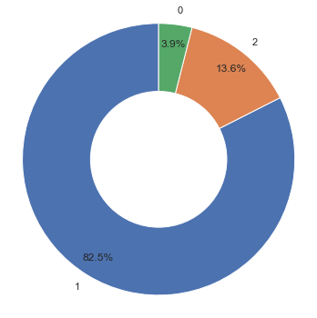

```python
def plot_class_dist(sizes, labels):
    # explode = [0.05]*len(val_counts.index)
    fig1, ax1 = plt.subplots(figsize=(5,5))
    ax1.pie(sizes,
            labels=labels,
            autopct='%1.1f%%',
            startangle=90,
    #         explode=explode,
            pctdistance=0.85)

    centre_circle = plt.Circle((0,0),0.50, fc='white')
    fig = plt.gcf()
    fig.gca().add_artist(centre_circle)

    ax1.axis('equal')
    plt.tight_layout()
    plt.show();

plot_class_dist(sizes, labels);
```

So, the data is not well distributed. It is called the **imbalanced class** problem. The dominant rating is **1=Good Quality**. To get a better accuracy from the model, we might need to balance the dataset using **sampling techniques (oversampling/undersampling)**.

Now, it's time for **data segregation**. We need to separate the feature columns and target column.

```python
X = data_clsf.loc[:, data_clsf.columns!='quality']
y = data_clsf.loc[:, data_clsf.columns=='quality']
```

So, let's jump to making the **traing and validation** dataset.

```python
from sklearn.model_selection import train_test_split

X_train, X_test, y_train, y_test = train_test_split(X, y, test_size=0.20,
                                                    stratify=y, random_state=1234)

print("""
X_train has {} data points.
y_train has {} data points.
X_test has {} data points.
y_test has {} data points.
""".format(X_train.shape[0], y_train.shape[0], X_test.shape[0], y_test.shape[0]))
```

```
X_train has 1279 data points.
y_train has 1279 data points.
X_test has 320 data points.
y_test has 320 data points.
```

### Step 4: Modeling

WOOOHAAA!!

Again, we've reached the modeling part! The easiest one!

We'll use **Decision Tree** algorithm for data modeling. This is one of the most powerful yet an easy model.

### Decision Tree

To demonstrate decision trees, let’s listen to the story of Sajid.

[figure not shown]

Here we can see the **amount of grocery items**, how was the **weather**, and whether Sajid went to **work** taht day. Green rows are days he went to the store and shopped the items, and red days are those he didn’t.

This is how a decition tree will get trained.

Let’s divide the first attribute up into a tree. Sajid can either have a low, medium, or high amount of items to shop:

[figure not shown]

Here we can see that Sajid never shoped if he had a high amount of items in the list. This is called a pure subset, a subset with only positive or only negative examples. With decision trees, there is no need to break a pure subset down further.

Let’s break the Med Items category into whether Sajid worked that day:

[figure not shown]

Here we can see we have two more pure subsets, so this tree is complete. We can replace any pure subsets with their respective answer - in this case, yes or no.

Finally, let’s split the Low Items category by the Weather attribute:

[figure not shown]

Now that we have all pure subsets, we can create our final decision tree:

[figure not shown]

The best thing about Decision Tree is you can extract the **feature importance** from the model and also interpret the tree for **extracting the underlying patterns** in data.

#### Let's train a Decision Tree to our data

```python
from sklearn.tree import DecisionTreeClassifier

clf_model = DecisionTreeClassifier(random_state=1234)
clf_model.fit(X_train, y_train)
```

```
DecisionTreeClassifier(class_weight=None, criterion='gini', max_depth=None,
            max_features=None, max_leaf_nodes=None,
            min_impurity_decrease=0.0, min_impurity_split=None,
            min_samples_leaf=1, min_samples_split=2,
            min_weight_fraction_leaf=0.0, presort=False, random_state=1234,
            splitter='best')
```

### Step 5: Validation

```python
y_pred = clf_model.predict(X_test)
```

There are wide variety of evaluation metrics for validating regression models such as **Accuracy, AUC, Precision, Recall, F1 score**. For our problem we'll use the **accuracy** metric.

**Remember:** Accuracy is not always the best metric to valiate classification model. Sometime, depending on the problem, you'll need to choose other metrics.

```python
from sklearn.metrics import accuracy_score

acc_score = accuracy_score(y_test, y_pred)

print("The accuracy score is {}".format(acc_score))
```

```
The accuracy score is 0.821875
```

### Let's make prediction on live data.

```python
live_data_clsf = pd.DataFrame({
  'fixed acidity': 7.4,
  'volatile acidity': 0.7,
  'citric acid': 0.0,
  'residual sugar': 1.9,
  'chlorides': 0.076,
  'free sulfur dioxide': 11.0,
  'total sulfur dioxide': 34.0,
  'density': 0.9978,
  'pH': 3.51,
  'sulphates': 0.56,
  'alcohol': 9.4
}, index = [0])

live_data_clsf
```

|  | fixed acidity | volatile acidity | citric acid | residual sugar | chlorides | free sulfur dioxide | total sulfur dioxide | density | pH | sulphates | alcohol |
| --- | --- | --- | --- | --- | --- | --- | --- | --- | --- | --- | --- |
| 0 | 7.4 | 0.7 | 0.0 | 1.9 | 0.076 | 11.0 | 34.0 | 0.9978 | 3.51 | 0.56 | 9.4 |

Now make prediction using the trained model.

```python
y_pred_live = clf_model.predict(live_data_clsf)
print(y_pred_live)
```

```
[1]
```

### Step 6: Communication

#### Get the Feature importance

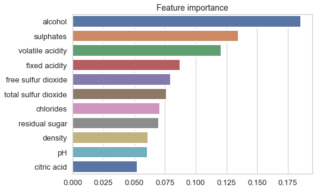

```python
coef = pd.Series(clf_model.feature_importances_, index = X.columns)
imp_coef = coef.sort_values(ascending=False)

def plot_importance(feat_imp, feat_name):
    fig, ax = plt.subplots(figsize=(8,5))
    sns.set(style="darkgrid", context="poster")
    sns.barplot(feat_imp, feat_name, palette="deep")
    plt.title("Feature importance", fontsize=14)
    plt.tick_params(axis='x', labelsize=13)
    plt.tick_params(axis='y', labelsize=13)
    plt.tight_layout()

plot_importance(imp_coef.values, imp_coef.index)
```

Let's generate a visualization of the tree.

```python
# # If you don't have pydotplus installed in your PC, please run the following command
# !pip install pydotplus
```

```python
from sklearn import tree
import pydotplus

dot_data = tree.export_graphviz(clf_model,
                                feature_names=X_train.columns,
                                out_file=None,
                                filled=True,
                                rounded=True)
graph = pydotplus.graph_from_dot_data(dot_data)
graph.write_svg('tree.svg')
```

```
True
```

# Case Study 3: Clustering

**Applications of Clustering Algorithm:**

- Market/Customer Segmentation
- Behavioural Segmentation
- Anomaly Detection
- Social Network Analysis

### Problem Description:

In this project, we will analyze a dataset containing data on various customers’ annual spending amounts (reported in monetary units) of diverse product categories for internal structure. One goal of this project is to best describe the variation in the different types of customers that a wholesale distributor interacts with. Doing so would equip the distributor with insight into how to best structure their delivery service to meet the needs of each customer.

#### Let's find the customer segments!!

### Step 1: Data Collection

```python
import pandas as pd

data_clst = pd.read_csv("data/clustering_wholesale_customers.csv")
```

### Step 2: Exploration (Exploratory Data Analysis)

Let's have a glance of the data.

```python
data_clst.head()
```

|  | Fresh | Milk | Grocery | Frozen | Detergents_Paper | Delicatessen |
| --- | --- | --- | --- | --- | --- | --- |
| 0 | 12669 | 9656 | 7561 | 214 | 2674 | 1338 |
| 1 | 7057 | 9810 | 9568 | 1762 | 3293 | 1776 |
| 2 | 6353 | 8808 | 7684 | 2405 | 3516 | 7844 |
| 3 | 13265 | 1196 | 4221 | 6404 | 507 | 1788 |
| 4 | 22615 | 5410 | 7198 | 3915 | 1777 | 5185 |

What about the data shape and datatypes?

```python
print("""
No of columns: {}
No of rows: {}
No of categorical columns: {}
No of numerical columns: {}""".format(data_clst.shape[1],
                                      data_clst.shape[0],
                                      len(data_clst.select_dtypes('O').columns),
                                      len(data_clst.select_dtypes(['int', 'float']).columns)))
```

```
No of columns: 6
No of rows: 435
No of categorical columns: 0
No of numerical columns: 6
```

Again, we don't have any categorical columns. That's easy!!

Let's have a descriptive statistical tables of the numeric columns.

```python
data_clst.describe().transpose()
```

|  | count | mean | std | min | 25% | 50% | 75% | max |
| --- | --- | --- | --- | --- | --- | --- | --- | --- |
| Fresh | 435.0 | 12089.372414 | 12662.796341 | 3.0 | 3208.0 | 8565.0 | 16934.5 | 112151.0 |
| Milk | 435.0 | 5788.103448 | 7374.172350 | 112.0 | 1579.5 | 3634.0 | 7168.0 | 73498.0 |
| Grocery | 435.0 | 7911.158621 | 9365.740973 | 218.0 | 2156.0 | 4757.0 | 10665.5 | 92780.0 |
| Frozen | 435.0 | 3096.126437 | 4873.769559 | 25.0 | 770.5 | 1541.0 | 3559.5 | 60869.0 |
| Detergents_Paper | 435.0 | 2848.473563 | 4679.364623 | 3.0 | 260.0 | 813.0 | 3935.0 | 40827.0 |
| Delicatessen | 435.0 | 1536.797701 | 2833.363881 | 3.0 | 411.5 | 967.0 | 1825.5 | 47943.0 |

How's the distribution of numerical columns?

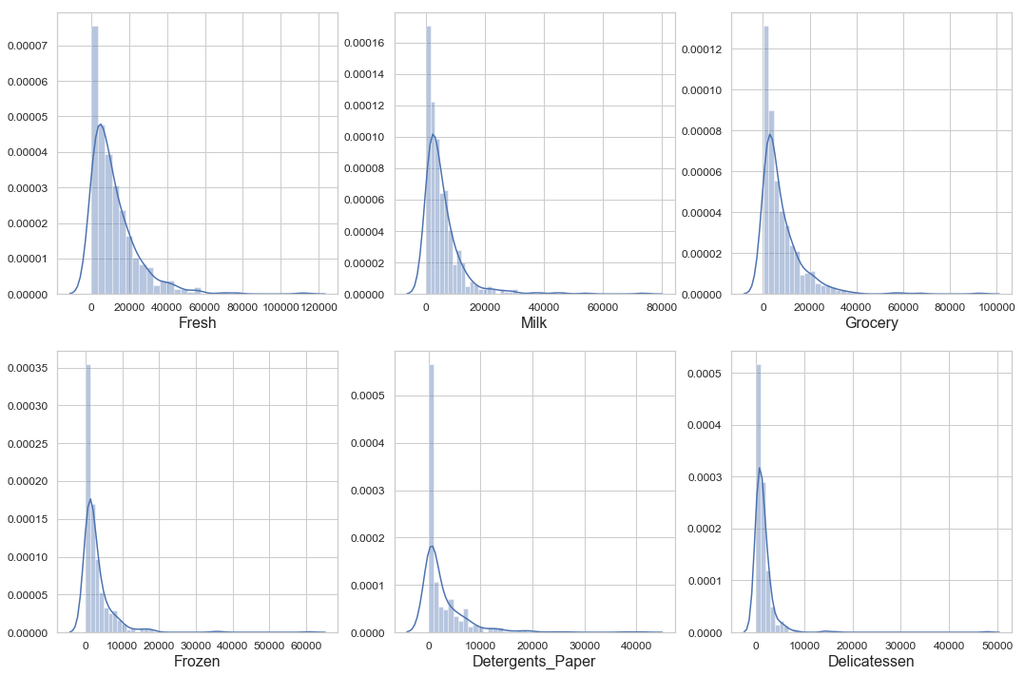

```python
import matplotlib.pyplot as plt
%matplotlib inline
import seaborn as sns
sns.set()
import numpy as np
import warnings
warnings.filterwarnings('ignore')

def plot_distribution(data, features):
    i = 0
    plt.figure()
    col = 3
    row = int(np.ceil(len(features)/col))
    fig, ax = plt.subplots(row,col,figsize=(18,12))
    sns.set_style("whitegrid")

    for feature in features:
        i += 1
        plt.subplot(row,col,i);
        sns.distplot(data[feature])
        plt.xlabel(feature, fontsize=16)
        locs, labels = plt.xticks()
        plt.tick_params(axis='x', which='major', labelsize=12)
        plt.tick_params(axis='y', which='major', labelsize=12)
    plt.show();

plot_distribution(data_clst, data_clst.columns)
```

Let's quickly check the correlations between the columns?

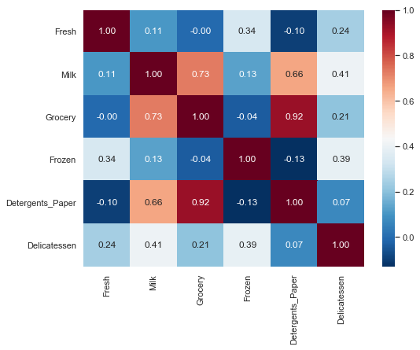

```python
corr = data_clst.corr()
fig, ax = plt.subplots(figsize=(8,6))
sns.heatmap(corr,
            xticklabels=corr.columns.values,
            yticklabels=corr.columns.values,
            annot=True, fmt=".2f", cmap="RdBu_r");
```

### Step 3: Preprocessing

Are there any **missing values**?

```python
pd.DataFrame(data_clst.isnull().sum(), columns=['Missing Values'])
```

|  | Missing Values |
| --- | --- |
| Fresh | 0 |
| Milk | 0 |
| Grocery | 0 |
| Frozen | 0 |
| Detergents_Paper | 0 |
| Delicatessen | 0 |

DAMN!! We are very lucky!! No missing values!

Wait, this is a unsupervised clustering problem. So we don't need any **data segregation**.

Clustering algorithms **calculates distance from the centroids**. So, it is **highly affective to scaling**. Now, we need to perform scaling on the data.

```python
from sklearn.preprocessing import StandardScaler
import numpy as np

scaler = StandardScaler()
scaler.fit(data_clst)
data_clst_scaled = scaler.transform(data_clst.values)
data_clst_scaled = pd.DataFrame(data_clst_scaled, columns=data_clst.columns)
```

### Step 4: Modeling

Now, the modeling part!

In this section, we will use a **K-Means** clustering algorithm to identify the various customer segments hidden in the data. We will then recover specific data points from the clusters to understand their significance by transforming them back into their original dimension and scale.

### K-Means clustering

**1. Specify the desired number of clusters K:** Let us choose k=2 for these 5 data points in 2-D space.

[figure not shown]

**2. Randomly assign each data point to a cluster:** Let’s assign three points in cluster 1 shown using red color and two points in cluster 2 shown using grey color.

[figure not shown]

**3. Compute cluster centroids:** The centroid of data points in the red cluster is shown using red cross and those in grey cluster using grey cross.

[figure not shown]

**4. Re-assign each point to the closest cluster centroid:** Note that only the data point at the bottom is assigned to the red cluster even though its closer to the centroid of grey cluster. Thus, we assign that data point into grey cluster.

[figure not shown]

**5. Re-compute cluster centroids:** Now, re-computing the centroids for both the clusters.

[figure not shown]

**6. Repeat steps 4 and 5 until no improvements are possible:** Similarly, we’ll repeat the $4th$ and $5th$ steps until we’ll reach global optima. When there will be no further switching of data points between two clusters for two successive repeats. It will mark the termination of the algorithm if not explicitly mentioned.

**Advantages of K-Means clustering**:

- Simple, easy to implement and interpret results.
- Good for hard cluster assignments i.e. when a data point only belongs to one cluster over the others.

#### Let's train a K-Means clustering to our data

Firstly, we need to find the number of $k$ clusters. How can we determine the value of $k$?

Using **elbow method**!!!

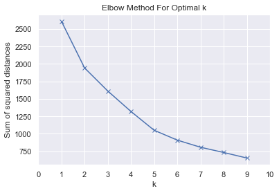

```python
from sklearn.cluster import KMeans

def plot_elbow(data):
    sum_of_squared_distances = []
    K = range(1,10)
    for k in K:
        km = KMeans(n_clusters=k, random_state=1234)
        km = km.fit(data)
        sum_of_squared_distances.append(km.inertia_)

    plt.figure(figsize=(6,4))
    sns.set(style="darkgrid")
    plt.plot(K, sum_of_squared_distances, 'bx-')
    plt.xlabel('k')
    plt.xlim(0,10)
    plt.xticks(np.arange(0,11,1))
    plt.ylabel('Sum of squared distances')
    plt.title('Elbow Method For Optimal k')
    plt.show();

plot_elbow(data_clst_scaled)
```

Now, train the clustering model using the determined value of $k$.

```python
from sklearn.cluster import KMeans

km = KMeans(n_clusters=2)
km.fit(data_clst_scaled)
```

```
KMeans(algorithm='auto', copy_x=True, init='k-means++', max_iter=300,
    n_clusters=2, n_init=10, n_jobs=None, precompute_distances='auto',
    random_state=None, tol=0.0001, verbose=0)
```

### Step 5: Validation (not actually; it may named as inference)

```python
preds = km.predict(data_clst_scaled)
labels = km.labels_
centers = km.cluster_centers_
```

As this is unspervised learning, we can not calculate accuracy or prediction errors. However, we can determine the quality of clustring by calculating Silhouette Score.

**The score is bounded between -1 for incorrect clustering and +1 for highly dense clustering. Scores around zero indicate overlapping clusters.**

```python
from sklearn.metrics import silhouette_score

silhouette = silhouette_score(data_clst, labels, metric='euclidean')

print(silhouette)
```

```
0.4964071097482141
```

```python
true_centers = scaler.inverse_transform(centers)

segments = ['Segment {}'.format(i+1) for i in range(0,len(true_centers))]
true_centers = pd.DataFrame(np.round(true_centers), columns=data_clst.keys())
true_centers.index = segments

true_centers
```

|  | Fresh | Milk | Grocery | Frozen | Detergents_Paper | Delicatessen |
| --- | --- | --- | --- | --- | --- | --- |
| Segment 1 | 12236.0 | 4020.0 | 5402.0 | 3086.0 | 1658.0 | 1267.0 |
| Segment 2 | 10985.0 | 19099.0 | 26801.0 | 3173.0 | 11815.0 | 3566.0 |

**Now, let's make inference from the segments**:

- **Segment 1**: This segment best represents retailers. Their spend on Fresh is the highest. Their spend on other categories are lower but close to mean and median.
- **Segment 2**: This segment best represents supermarkets. They spend the higher than mean and median amount on Milk, Grocery, Frozen, Detergents_Paper and Delicassen, which are both essential to be stocked in such places.

```python
data_clst.describe().transpose()
```

|  | count | mean | std | min | 25% | 50% | 75% | max |
| --- | --- | --- | --- | --- | --- | --- | --- | --- |
| Fresh | 435.0 | 12089.372414 | 12662.796341 | 3.0 | 3208.0 | 8565.0 | 16934.5 | 112151.0 |
| Milk | 435.0 | 5788.103448 | 7374.172350 | 112.0 | 1579.5 | 3634.0 | 7168.0 | 73498.0 |
| Grocery | 435.0 | 7911.158621 | 9365.740973 | 218.0 | 2156.0 | 4757.0 | 10665.5 | 92780.0 |
| Frozen | 435.0 | 3096.126437 | 4873.769559 | 25.0 | 770.5 | 1541.0 | 3559.5 | 60869.0 |
| Detergents_Paper | 435.0 | 2848.473563 | 4679.364623 | 3.0 | 260.0 | 813.0 | 3935.0 | 40827.0 |
| Delicatessen | 435.0 | 1536.797701 | 2833.363881 | 3.0 | 411.5 | 967.0 | 1825.5 | 47943.0 |

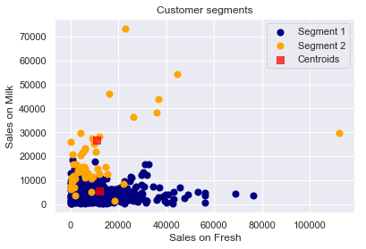

```python
plt.scatter(data_clst[preds==0]['Fresh'], data_clst[preds==0]['Milk'],
            c='navy', s=50, label='Segment 1')

plt.scatter(data_clst[preds==1]['Fresh'], data_clst[preds==1]['Milk'],
            c='orange', s=50, label='Segment 2')

plt.scatter(true_centers['Fresh'],
            true_centers['Grocery'],
            s=50, marker='s', c='red',
            alpha=0.7, label='Centroids')

plt.title('Customer segments')
plt.xlabel('Sales on Fresh')
plt.ylabel('Sales on Milk')
plt.legend()
plt.show()
```

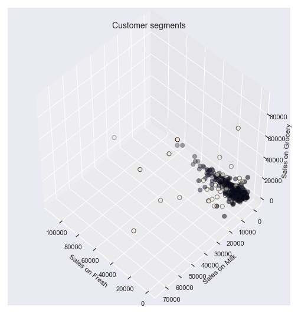

```python
from mpl_toolkits.mplot3d import Axes3D

fig = plt.figure(1, figsize=(7,7))
ax = Axes3D(fig, rect=[0, 0, .95, 1], elev=48, azim=134)
ax.scatter(data_clst['Fresh'],
           data_clst['Milk'],
           data_clst['Grocery'],
           c=labels.astype(np.float),
           edgecolor="k", s=50)

ax.set_xlabel("Sales on Fresh")
ax.set_ylabel("Sales on Milk")
ax.set_zlabel("Sales on Grocery")
plt.title("Customer segments", fontsize=14)
plt.show();
```

## Learning Resources

- [Machine Learning](https://www.coursera.org/learn/machine-learning)
- [Applied Data Science with Python Specialization](https://www.coursera.org/specializations/data-science-python)
- [Mathematics for Machine Learning Specialization](https://www.coursera.org/specializations/mathematics-machine-learning)
- [Data Science Essentials](https://www.edx.org/course/data-science-essentials)
- [Intro to Data Science](https://www.udacity.com/course/intro-to-data-science--ud359)

## Conducting research in Applied Data Science and Machine Learning

### In Data Science research can be categorized into two types:

- **Pure Research:** You need to bring innovation and algorithmic change.
- **Applied research:** You need to apply ML methods to solve innovative/impactful problems.

### Research articles can be (basically) categorized into three types:

- **Journal Paper:** The articles are long (typically 10+ pages). Very rigorous and long review periods. They usually expect innovation and algorithmic development. Some journals asks for article processing fees.
- **Review Paper:** You need to find and analyze hundreds of papers from previous 5/10/15 years on your topic of interest. Critically analyze their approaches and summerize and criticize. You need to be very strong in english.
- **Conference Paper:** This is the shorter version. Most of the conference papers accepts applied research works. Typically bouned to 4-6 pages. After draft paper submission, your paper will have to pass the review process (1-2 months). If your paper get the acceptance, you'll need to attend the confernce and present your paper. The conference registration fee is a must.

### How to choose good journals and conferences?

- Indexing: Scopus, IEEE, ACM, EI, ISI, DBLP
- Quartiles, Impact Factors and H-Index
- Age of the conference/journals

### Important Websites

- https://www.scimagojr.com/
- http://dblp.org
- http://wikicfp.com
- http://guide2research.com
- https://researchgate.net

### Popular conferences for Data Science & Machine Learning

- [SIGKDD](https://www.kdd.org/kdd2019/): ACM SIGKDD Conference on Knowledge Discovery and Data Mining
- [ICDE](http://conferences.cis.umac.mo/icde2019/): International Conference on Data Engineering
- [ICDM](http://icdm2018.org): International Conference on Data Mining
- [CKIM](http://www.cikm2019.net): International Conference on Information and Knowledge Management
- [ICML](https://icml.cc): International Conference on Machine Learning
- [NeurIPS (NIPS)](https://nips.cc/): Conference on Neural Information Processing Systems
- [CVPR](https://www.thecvf.com/): Conference on Computer Vision and Pattern Recognition
- [AAAI](https://aaai.org/Conferences/AAAI/aaai.php): Association for the Advancement of Artificial Intelligence
- [ICLR](https://iclr.cc/): International Conference on Learning Representations

If you are interested in applied research in Data Science and Machine Learning, feel free to knock me (abdalimran@gmail.com). I can supervise your research projects. I'm always looking for dedicated collaborators and research groups.

# Good luck future Data Scientists!!

[figure not shown]